# 27_novelties_outliers

### [Outlier Detection: Method Comparison](https://scikit-learn.org/stable/auto_examples/miscellaneous/plot_anomaly_comparison.html)

- Each dataset has 15% of samples generated with random uniform noise.
- Decision boundaries between inliers and outliers are displayed in black except for Local Outlier Factor (LOF) - it has no predict method for new data.
- **OneClassSVM** is sensitive to outliers - it does not perform well. It is *best suited for novelty detection when the training set is not contaminated by outliers*.
- That said, outlier detection in high-dimension, or without any assumptions on the distribution of the inlying data is very challenging. One-class SVM might give useful results in these situations.
- **EllipticEnvelope** assumes the data is Gaussian and learns an ellipse. It degrades when the data is not unimodal. It is robust to outliers.
- **IsolationForest** & **LocalOutlierFactor** perform reasonably well for *multi-modal datasets*. Its advantage is shown in the third data set *where the two modes have different densities*.
- This is explained by the *local aspect of LOF* - it only compares the abnormality score of one sample with the scores of its neighbors.
- The last dataset is *uniformly distributed in a hypercube*. Except for the OneClassSVM which overfits a little, all estimators present decent solutions. Look closely at the abnormality scores - a good estimator should assign similar scores to all the samples.
- Note: the model parameters are handpicked - in practice they need to be adjusted. In the absence of labelled data, the problem is completely unsupervised so model selection can be a challenge.

```python
import time
import numpy as np
import matplotlib
import matplotlib.pyplot as plt
from sklearn import svm
from sklearn.datasets import make_moons, make_blobs
from sklearn.covariance import EllipticEnvelope
from sklearn.ensemble import IsolationForest
from sklearn.neighbors import LocalOutlierFactor
```

```python
matplotlib.rcParams['contour.negative_linestyle'] = 'solid'

# Example settings
n_samples = 300
outliers_fraction = 0.15
n_outliers = int(outliers_fraction * n_samples)
n_inliers = n_samples - n_outliers
```

```python
anomaly_algorithms = [
    ("Robust covariance",
     EllipticEnvelope(contamination=outliers_fraction)),
    ("One-Class SVM",
     svm.OneClassSVM(nu=outliers_fraction,
                     kernel="rbf",
                     gamma=0.1)),
    ("Isolation Forest",
     IsolationForest(contamination=outliers_fraction,
                     random_state=42)),
    ("Local Outlier Factor", LocalOutlierFactor(
        n_neighbors=35,
        contamination=outliers_fraction))]

# Define datasets
blobs_params = dict(random_state=0, n_samples=n_inliers, n_features=2)
datasets = [
    make_blobs(centers=[[0, 0], [0, 0]],
               cluster_std=0.5,
               **blobs_params)[0],
    make_blobs(centers=[[2, 2], [-2, -2]],
               cluster_std=[0.5, 0.5],
               **blobs_params)[0],
    make_blobs(centers=[[2, 2], [-2, -2]],
               cluster_std=[1.5, .3],
               **blobs_params)[0],
    4.0*(make_moons(n_samples=n_samples,
                    noise=.05,
                    random_state=0)[0] - np.array([0.5, 0.25])),
    14.0*(np.random.RandomState(42).rand(n_samples, 2) - 0.5)]
```

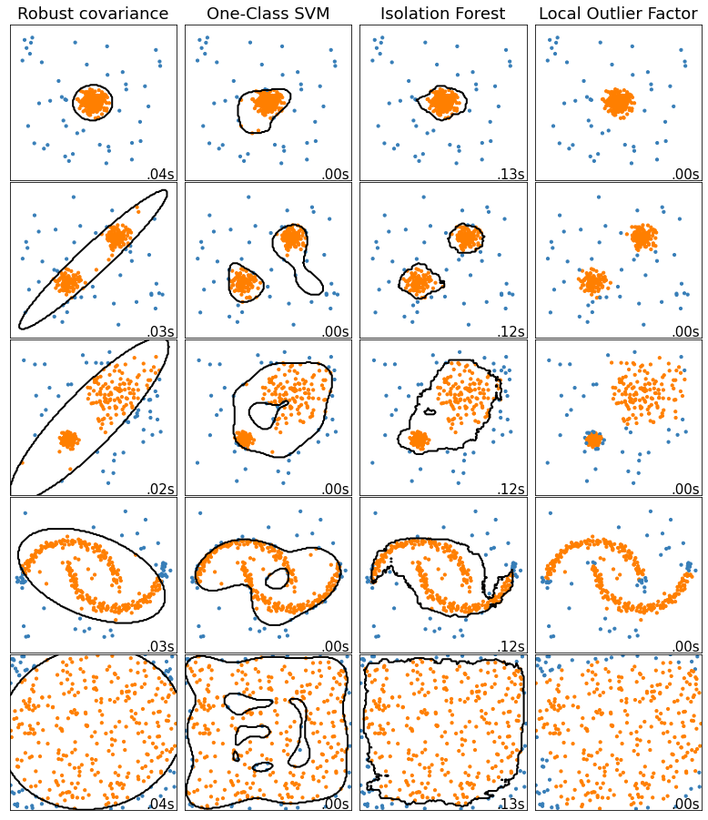

```python
xx, yy = np.meshgrid(np.linspace(-7, 7, 150),
                     np.linspace(-7, 7, 150))

plt.figure(figsize=(len(anomaly_algorithms)*2+3, 12.5))
plt.subplots_adjust(left=.02, right=.98, bottom=.001, top=.96,
                    wspace=.05, hspace=.01)

plot_num = 1
rng = np.random.RandomState(42)

for i_dataset, X in enumerate(datasets):

    X = np.concatenate([X,
                        rng.uniform(low=-6, high=6,
                                    size=(n_outliers, 2))],
                       axis=0)

    for name, algorithm in anomaly_algorithms:
        t0 = time.time()
        algorithm.fit(X)
        t1 = time.time()
        plt.subplot(len(datasets), len(anomaly_algorithms), plot_num)
        if i_dataset == 0:
            plt.title(name, size=18)

        if name == "Local Outlier Factor":
            y_pred = algorithm.fit_predict(X)
        else:
            y_pred = algorithm.fit(X).predict(X)

        if name != "Local Outlier Factor":  # LOF does not implement predict
            Z = algorithm.predict(np.c_[xx.ravel(),
                                        yy.ravel()])
            Z = Z.reshape(xx.shape)
            plt.contour(xx, yy, Z, levels=[0],
                        linewidths=2, colors='black')

        colors = np.array(['#377eb8', '#ff7f00'])
        plt.scatter(X[:, 0],
                    X[:, 1],
                    s=10, color=colors[(y_pred + 1) // 2])

        plt.xlim(-7, 7);
        plt.ylim(-7, 7)
        plt.xticks(())
        plt.yticks(())
        plt.text(.99, .01, ('%.2fs' % (t1 - t0)).lstrip('0'),
                 transform=plt.gca().transAxes, size=15,
                 horizontalalignment='right')
        plot_num += 1
```

### [Novelty Detection - OneClass SVM](https://scikit-learn.org/stable/modules/generated/sklearn.svm.OneClassSVM.html#sklearn.svm.OneClassSVM)

- Consider a dataset from a single distribution. Are new observations so different that we can doubt it comes from the same distribution?
- **One-Class SVM** requires the choice of a kernel (typically, RBF) and a scalar parameter to define a frontier.
- `nu` (aka the margin) corresponds to the probability of finding a new, but regular, observation outside the frontier.

### [Example: One Class SVM / RBF kernel](https://scikit-learn.org/stable/auto_examples/svm/plot_oneclass.html#sphx-glr-auto-examples-svm-plot-oneclass-py)

```python
import numpy as np
import matplotlib.pyplot as plt
import matplotlib.font_manager
from sklearn import svm

xx, yy = np.meshgrid(np.linspace(-5, 5, 500),
                     np.linspace(-5, 5, 500))

# numpy.r_: Translates slice objects to concatenation along the first axis.

X          = 0.3*np.random.randn(100, 2);  X_train    = np.r_[X+2, X-2]
X          = 0.3*np.random.randn( 20, 2);  X_test     = np.r_[X+2, X-2]
X_outliers = np.random.uniform(low=-4, high=4, size=(20, 2))

clf = svm.OneClassSVM(nu=0.1, kernel="rbf", gamma=0.1).fit(X_train)

y_pred_train     = clf.predict(X_train)
y_pred_test      = clf.predict(X_test)
y_pred_outliers  = clf.predict(X_outliers)

n_error_train    = y_pred_train[   y_pred_train    == -1].size
n_error_test     = y_pred_test[    y_pred_test     == -1].size
n_error_outliers = y_pred_outliers[y_pred_outliers == 1].size

# plot the line, the points, and the nearest vectors to the plane
Z = clf.decision_function(np.c_[xx.ravel(),
                                yy.ravel()])
Z = Z.reshape(xx.shape)
```

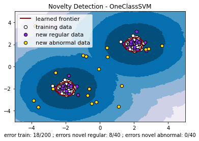

```python
plt.title("Novelty Detection - OneClassSVM")
plt.contourf(xx, yy, Z, levels=np.linspace(Z.min(), 0, 7), cmap=plt.cm.PuBu)
plt.contourf(xx, yy, Z, levels=[0, Z.max()], colors='palevioletred')

a = plt.contour(xx, yy, Z, levels=[0], linewidths=2, colors='darkred')

s = 40
b1 = plt.scatter(X_train[   :, 0], X_train[   :, 1], c='white',      s=s, edgecolors='k')
b2 = plt.scatter(X_test[    :, 0], X_test[    :, 1], c='blueviolet', s=s, edgecolors='k')
c  = plt.scatter(X_outliers[:, 0], X_outliers[:, 1], c='gold',       s=s, edgecolors='k')

plt.axis('tight')
plt.xlim((-5, 5))
plt.ylim((-5, 5))

plt.legend([a.collections[0], b1, b2, c],
           ["learned frontier", "training data",
            "new regular data", "new abnormal data"],
           loc="upper left",
           prop=matplotlib.font_manager.FontProperties(size=11))
plt.xlabel(
    "error train: %d/200 ; errors novel regular: %d/40 ; "
    "errors novel abnormal: %d/40"
    % (n_error_train, n_error_test, n_error_outliers))
```

### [Example: Species geographic distribution modeling](https://scikit-learn.org/stable/auto_examples/applications/plot_species_distribution_modeling.html#sphx-glr-auto-examples-applications-plot-species-distribution-modeling-py)

- Two South American mammals with past observations & 14 environmental variables.
- Only positive samples (no unsuccessful observations) - treat problem as density estimation & use **OneClassSVM**
- Use **basemap** to plot geography outlines.

```python
from time import time
import numpy as np
import matplotlib.pyplot as plt
from sklearn.utils import Bunch
from sklearn.datasets import fetch_species_distributions
from sklearn import svm, metrics
# if basemap is available, we'll use it. otherwise, we'll improvise later...
try:
    from mpl_toolkits.basemap import Basemap
    basemap = True
except ImportError:
    basemap = False
```

```python
# Construct map grid from batch object
# params: batch : object returned by :func:`fetch_species_distributions`
# returns: (xgrid, ygrid) : 1-D arrays = values in batch.coverages

def construct_grids(batch):
    xmin = batch.x_left_lower_corner + batch.grid_size
    ymin = batch.y_left_lower_corner + batch.grid_size
    xmax = xmin                      + (batch.Nx * batch.grid_size)
    ymax = ymin                      + (batch.Ny * batch.grid_size)

    xgrid = np.arange(xmin, xmax, batch.grid_size)
    ygrid = np.arange(ymin, ymax, batch.grid_size)

    return (xgrid, ygrid)

# Create bunch with info about specified organism
# Uses test/train record arrays to extract species data

def create_species_bunch(species_name, train, test, coverages, xgrid, ygrid):
    bunch        = Bunch(name=' '.join(species_name.split("_")[:2]))
    species_name = species_name.encode('ascii')
    points       = dict(test=test, train=train)

    for label, pts in points.items():
        # choose points associated with the desired species
        pts = pts[pts['species'] == species_name]
        bunch['pts_%s' % label] = pts

        # determine coverage values for each of the training & testing points
        ix = np.searchsorted(xgrid, pts['dd long'])
        iy = np.searchsorted(ygrid, pts['dd lat'])
        bunch['cov_%s' % label] = coverages[:, -iy, ix].T

    return bunch
```

```
from coverage

 Area under the ROC curve : 0.868443
from coverage

 Area under the ROC curve : 0.993919

time elapsed: 4.33s
```

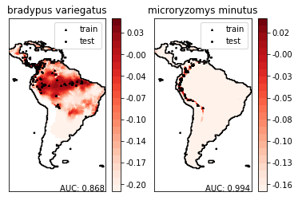

```python
def plot_species_distribution(species=("bradypus_variegatus_0",
                                       "microryzomys_minutus_0")):
    if len(species) > 2:
        print("When >2 species are provided, only 1st 2 will be used")

    t0 = time()
    data = fetch_species_distributions()
    xgrid, ygrid = construct_grids(data)
    X, Y = np.meshgrid(xgrid, ygrid[::-1])

    BV_bunch = create_species_bunch(species[0],
                                    data.train, data.test,
                                    data.coverages, xgrid, ygrid)
    MM_bunch = create_species_bunch(species[1],
                                    data.train, data.test,
                                    data.coverages, xgrid, ygrid)

    np.random.seed(13)
    background_points = np.c_[np.random.randint(low=0, high=data.Ny,
                                                size=10000),
                              np.random.randint(low=0, high=data.Nx,
                                                size=10000)].T

    # We'll make use of the fact that coverages[6] has measurements at all
    # land points.  This will help us decide between land and water.
    land_reference = data.coverages[6]

    for i, species in enumerate([BV_bunch, MM_bunch]):

        mean            = species.cov_train.mean(axis=0)
        std             = species.cov_train.std(axis=0)
        train_cover_std = (species.cov_train - mean) / std

        # Fit OneClassSVM
        clf = svm.OneClassSVM(nu=0.1, kernel="rbf", gamma=0.5)
        clf.fit(train_cover_std)

        # Plot map of South America
        plt.subplot(1, 2, i + 1)
        if basemap:
            print("using basemap")
            m = Basemap(projection='cyl', llcrnrlat=Y.min(),
                        urcrnrlat=Y.max(), llcrnrlon=X.min(),
                        urcrnrlon=X.max(), resolution='c')
            m.drawcoastlines()
            m.drawcountries()
        else:
            print("from coverage")
            plt.contour(X, Y, land_reference,
                        levels=[-9998], colors="k",
                        linestyles="solid")
            plt.xticks([])
            plt.yticks([])

        Z = np.ones((data.Ny, data.Nx), dtype=np.float64)

        # We'll predict only for the land points.
        idx = np.where(land_reference > -9999)
        coverages_land = data.coverages[:, idx[0], idx[1]].T

        pred = clf.decision_function((coverages_land - mean) / std)
        Z *= pred.min()
        Z[idx[0], idx[1]] = pred

        levels = np.linspace(Z.min(), Z.max(), 25)
        Z[land_reference == -9999] = -9999

        # plot contours of the prediction
        plt.contourf(X, Y, Z, levels=levels, cmap=plt.cm.Reds)
        plt.colorbar(format='%.2f')

        # scatter training/testing points
        plt.scatter(species.pts_train['dd long'], species.pts_train['dd lat'],
                    s=2 ** 2, c='black',
                    marker='^', label='train')
        plt.scatter(species.pts_test['dd long'], species.pts_test['dd lat'],
                    s=2 ** 2, c='black',
                    marker='x', label='test')
        plt.legend()
        plt.title(species.name)
        plt.axis('equal')

        # Compute AUC with regards to background points
        pred_background = Z[background_points[0], background_points[1]]
        pred_test = clf.decision_function((species.cov_test - mean) / std)
        scores = np.r_[pred_test, pred_background]
        y = np.r_[np.ones(pred_test.shape), np.zeros(pred_background.shape)]
        fpr, tpr, thresholds = metrics.roc_curve(y, scores)
        roc_auc = metrics.auc(fpr, tpr)
        plt.text(-35, -70, "AUC: %.3f" % roc_auc, ha="right")
        print("\n Area under the ROC curve : %f" % roc_auc)

    print("\ntime elapsed: %.2fs" % (time() - t0))


plot_species_distribution()
```

### [Outlier Detection with Elliptic Envelope](https://scikit-learn.org/stable/modules/generated/sklearn.covariance.EllipticEnvelope.html#sklearn.covariance.EllipticEnvelope)

- Similar to novelty detection - the goal is to separate "good" observations from polluting ones. *We don’t have a clean dataset* to train any tool.
- One approach is to assume the good data comes from a known distribution (e.g. data are Gaussian distributed). We can use this to define the “shape” of the data - and can define data sufficiently far from the shape to be outliers.
- EllipticEnvelope fits a robust covariance estimate to the data - thereby fitting an ellipse to the central data points.
- This method uses Mahalanobis distances to derive a distance measure.

### [Example: Elliptic Envelope](https://scikit-learn.org/stable/auto_examples/applications/plot_outlier_detection_wine.html#sphx-glr-auto-examples-applications-plot-outlier-detection-wine-py)

```python
import numpy as np
from sklearn.covariance import EllipticEnvelope
from sklearn.svm import OneClassSVM
import matplotlib.pyplot as plt
import matplotlib.font_manager
from sklearn.datasets import load_wine
```

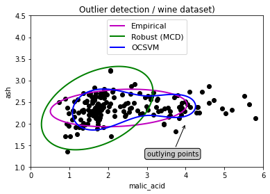

```python
classifiers = {
    "Empirical":    EllipticEnvelope(contamination=0.25, support_fraction=1.0),
    "Robust (MCD)": EllipticEnvelope(contamination=0.25),
    "OCSVM":        OneClassSVM(nu=0.25, gamma=0.35)}

colors           = ['m', 'g', 'b']
legend1, legend2 = {},{}
X1               = load_wine()['data'][:, [1, 2]]  # two clusters

# Learn a frontier for outlier detection with several classifiers
xx1, yy1 = np.meshgrid(np.linspace(0, 6, 500),
                       np.linspace(1, 4.5, 500))
for i, (clf_name, clf) in enumerate(classifiers.items()):
    plt.figure(1)
    clf.fit(X1)
    Z1 = clf.decision_function(np.c_[xx1.ravel(),
                                     yy1.ravel()])
    Z1 = Z1.reshape(xx1.shape)
    legend1[clf_name] = plt.contour(
        xx1, yy1, Z1,
        levels=[0], linewidths=2, colors=colors[i])

legend1_values_list = list(legend1.values())
legend1_keys_list   = list(legend1.keys())

plt.figure(1)  # two clusters
plt.title("Outlier detection / wine dataset)")
plt.scatter(X1[:, 0], X1[:, 1], color='black')
bbox_args  = dict(boxstyle="round", fc="0.8")
arrow_args = dict(arrowstyle="->")

plt.annotate("outlying points", xy=(4, 2),
             xycoords="data", textcoords="data",
             xytext=(3, 1.25), bbox=bbox_args, arrowprops=arrow_args)
plt.xlim((xx1.min(), xx1.max()))
plt.ylim((yy1.min(), yy1.max()))
plt.legend((legend1_values_list[0].collections[0],
            legend1_values_list[1].collections[0],
            legend1_values_list[2].collections[0]),
           (legend1_keys_list[0], legend1_keys_list[1], legend1_keys_list[2]),
           loc="upper center",
           prop=matplotlib.font_manager.FontProperties(size=11))
plt.ylabel("ash")
plt.xlabel("malic_acid")
```

### [Isolation Forest](https://scikit-learn.org/stable/modules/generated/sklearn.ensemble.IsolationForest.html#sklearn.ensemble.IsolationForest)

- Especially useful in high-dimensional problems.
- ‘isolates’ observations by randomly selecting a feature, then randomly selecting a split value between the [max,min] values of the feature.
- Recursive partitioning can be represented with a tree structure - the #splits required to isolate a sample *equals the path length* from the root to the terminating node. This value, averaged over a forest of such trees, is a measure of normality and our decision function.
- Random partitioning produces *noticeably shorter paths for anomalies*. Hence, when a forest of random trees returns shorter path lengths for particular samples, they are highly likely to be anomalies.
- This implementation is based on ExtraTreeRegressor. The max depth of each tree is set to the #samples used to build the tree (see Liu et al., 2008 for details).

### [Example: Isolation Forest](https://scikit-learn.org/stable/auto_examples/ensemble/plot_isolation_forest.html)

```python
import numpy as np
import matplotlib.pyplot as plt
from sklearn.ensemble import IsolationForest

rng = np.random.RandomState(42)
X = 0.3*rng.randn(100, 2);   X_train = np.r_[X+2, X-2]
X = 0.3*rng.randn( 20, 2);   X_test  = np.r_[X+2, X-2]
X_outliers = rng.uniform(low=-4, high=4, size=(20, 2))
```

```python
clf = IsolationForest(max_samples=100, random_state=rng).fit(X_train)
y_pred_train    = clf.predict(X_train)
y_pred_test     = clf.predict(X_test)
y_pred_outliers = clf.predict(X_outliers)

xx, yy = np.meshgrid(np.linspace(-5, 5, 50),
                     np.linspace(-5, 5, 50))
Z      = clf.decision_function(np.c_[xx.ravel(), yy.ravel()])
Z      = Z.reshape(xx.shape)
```

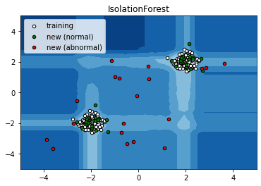

```python
plt.title("IsolationForest")
plt.contourf(xx, yy, Z, cmap=plt.cm.Blues_r)

b1 = plt.scatter(X_train[   :, 0], X_train[   :, 1], c='white', s=20, edgecolor='k')
b2 = plt.scatter(X_test[    :, 0], X_test[    :, 1], c='green', s=20, edgecolor='k')
c = plt.scatter( X_outliers[:, 0], X_outliers[:, 1], c='red',   s=20, edgecolor='k')
plt.axis('tight')
plt.xlim((-5, 5))
plt.ylim((-5, 5))
plt.legend([b1, b2, c],
           ["training", "new (normal)", "new (abnormal)"],
           loc="upper left")
```

### [Local Outlier Factor (LOF)](https://scikit-learn.org/stable/modules/generated/sklearn.neighbors.LocalOutlierFactor.html#sklearn.neighbors.LocalOutlierFactor)

- Another efficient way to perform outlier detection on moderately high dimensional datasets is to use the Local Outlier Factor (LOF) algorithm.
- Computes a *score* that describes *a degree of abnormality* of the observations. It measures the *local density deviation* of a given data point vs its neighbors. The idea is to detect samples with a substantially lower density than their neighbors.
- In practice the local density is obtained from `k-nearest neighbors`. A LOF score equals the ratio of the *average local density*: a normal instance should have a local density similar to that of its neighbors - abnormal data should have much smaller local density.
- `n_neighbors` is chosen 1) *greater than the minimum #objects a cluster has to contain* (so that other objects can be local outliers relative to this cluster), and 2) *smaller than the maximum #nearby objects that can potentially be local outliers*.
- This info is typically not available. Using `n_neighbors=20` is a good start. If the proportion of outliers is high (maybe >10%), `n_neighbors` should be greater (maybe>35).
- LOF considers both the local and global properties of datasets - it can perform well even when abnormal samples have different underlying densities. The question is not how isolated the sample is - but how isolated it is with respect to the surrounding neighborhood.
- LOF has no `predict`, `decision_function` and `score_samples` methods - only a `fit_predict` method. Training data abnormality scores are available via `negative_outlier_factor_`.
- `predict`, `decision_function` and `score_samples` can be used on new unseen data when LOF is applied for novelty detection (when `novelty=True`).

```python
import numpy as np
import matplotlib.pyplot as plt
from sklearn.neighbors import LocalOutlierFactor as LOF

np.random.seed(42)

X_inliers    = 0.3*np.random.randn(100, 2)
X_inliers    = np.r_[X_inliers+2,
                     X_inliers-2]
X_outliers   = np.random.uniform(low=-4, high=4, size=(20, 2))
X            = np.r_[X_inliers,
                     X_outliers]
n_outliers   = len(X_outliers)
ground_truth = np.ones(len(X), dtype=int)
ground_truth[-n_outliers:] = -1

clf = LOF(n_neighbors=20, contamination=0.1)

# use fit_predict to compute predicted labels of training samples
# (when LOF is used for outlier detection, the estimator has no predict,
# decision_function and score_samples methods).
y_pred   = clf.fit_predict(X)
n_errors = (y_pred != ground_truth).sum()
X_scores = clf.negative_outlier_factor_
```

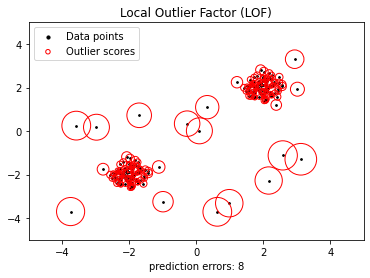

```python
plt.title("Local Outlier Factor (LOF)")
plt.scatter(X[:, 0],
            X[:, 1],
            color='k', s=3., label='Data points')

# plot circles with radius proportional to the outlier scores
radius = (X_scores.max() - X_scores) / (X_scores.max() - X_scores.min())

plt.scatter(X[:, 0],
            X[:, 1],
            s=1000 * radius, edgecolors='r',
            facecolors='none', label='Outlier scores')
plt.axis('tight')
plt.xlim((-5, 5))
plt.ylim((-5, 5))
plt.xlabel("prediction errors: %d" % (n_errors))
legend = plt.legend(loc='upper left')
legend.legendHandles[0]._sizes = [10]
legend.legendHandles[1]._sizes = [20]
```

### Local Outlier Factor / Novelty Detection

- To use LOF for novelty detection (predicting labels, abnormality scores of new unseen data), build an estimator with `novelty=True` before fitting.
- Only use `predict`, `decision_function` and `score_samples` on *new, unseen data* - NOT on training samples. This would lead to wrong results.
- Abnormality scores of training samples are available via `negative_outlier_factor_`.

```python
import numpy as np
import matplotlib
import matplotlib.pyplot as plt
from sklearn.neighbors import LocalOutlierFactor as LOF
```

```python
np.random.seed(42)

xx, yy = np.meshgrid(np.linspace(-5, 5, 500),
                     np.linspace(-5, 5, 500))

X = 0.3*np.random.randn(100, 2);  X_train = np.r_[X+2, X-2]
X = 0.3*np.random.randn( 20, 2);  X_test  = np.r_[X+2, X-2]
X_outliers = np.random.uniform(low=-4, high=4, size=(20, 2))

clf = LOF(n_neighbors=20,
          novelty=True,
          contamination=0.1).fit(X_train)

# DO NOT use predict, decision_function and score_samples on X_train as this
# would give wrong results but only on new unseen data (not used in X_train),
# e.g. X_test, X_outliers or the meshgrid
y_pred_test      = clf.predict(X_test)
y_pred_outliers  = clf.predict(X_outliers)
n_error_test     = y_pred_test[y_pred_test == -1].size
n_error_outliers = y_pred_outliers[y_pred_outliers == 1].size

Z = clf.decision_function(np.c_[xx.ravel(),
                                yy.ravel()])
Z = Z.reshape(xx.shape)
```

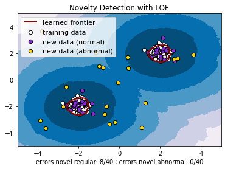

```python
plt.title("Novelty Detection with LOF")
plt.contourf(xx, yy, Z,
             levels=np.linspace(Z.min(), 0, 7),
             cmap=plt.cm.PuBu)

a = plt.contour(xx, yy, Z, levels=[0], linewidths=2, colors='darkred')
plt.contourf(   xx, yy, Z, levels=[0, Z.max()], colors='palevioletred')

s = 40
b1 = plt.scatter(X_train[:, 0], X_train[:, 1], c='white', s=s, edgecolors='k')
b2 = plt.scatter(X_test[ :, 0], X_test[:, 1], c='blueviolet', s=s, edgecolors='k')
c = plt.scatter(X_outliers[:, 0], X_outliers[:, 1], c='gold', s=s, edgecolors='k')
plt.axis('tight')
plt.xlim((-5, 5))
plt.ylim((-5, 5))
plt.legend([a.collections[0], b1, b2, c],
           ["learned frontier", "training data",
            "new data (normal)", "new data (abnormal)"],
           loc="upper left",
           prop=matplotlib.font_manager.FontProperties(size=11))
plt.xlabel(
    "errors novel regular: %d/40 ; errors novel abnormal: %d/40"
    % (n_error_test, n_error_outliers))
```